# Seminario:Calidad del Aire y Defunciones por Enfermedades Respiratorias

Repositorio: [GitHub](https://github.com/MinayaMR/Seminario)

Aya Toussi

Minaya Moreno Romero

Vanessa Pérez Paredes

2023-12-11

## **INTRODUCCIÓN:**

En este seminario se ha recopilado información y llevado a cabo un análisis sobre la calidad del aire en las diferentes comunidades autónomas de España Peninsular y la tasa de muertes por enfermedades respiratorias a lo largo de varios años en dichas regiones.

Finalmente se ha explorado la relación existente entre la calidad del aire y la mencionada tasa de mortalidad.

## **OBJETIVO GENERAL:**

Los objetivos generales de este seminario han sido:

- El estudio de la evolución de las defunciones por comunidades autónomas a lo largo de los años.
- El estudio de la calidad del aire según la concentración de gases obtenida en cada comunidad autónoma y como cambia a lo largo de los años.
- **Objetivo principal:** Analizar y examinar ambos sets de datos y determinar si existe una relación directa entre la calidad del aire que respire la población de cada comunidad autónoma y su tasa de defunción por enfermedades respiratorias.

## **METODOLOGíA :**

### Metodologías del Primer Objetivo General:

- Descargar los archivos en formato .csv que contienen las informaciones de defunciones anuales por Enfermedades Respiratorias para cada Comunidad Autónoma de España Peninsular desde 2010 a 2019. Estas tablas se han obtenido en totalidad a través de la página oficial del INEbase que es el sistema utilizado por el INE (Instituto Nacional de Estadística) para el almacenamiento de la información estadística en Internet. [Enlace directo al recurso utilizado para descargar los archivos](https://www.ine.es/jaxiT3/Tabla.htm?t=10803&L=0)
- Filtrar y cargar los datos para cada Comunidad Autónoma,organizarlos por años y por Comunidades en dataframes para cada año del 2010 al 2019.
- Representar la evolución de la tasa de Mortalidad obtenida en las diferentes Comunidades Autónomas para cada año en unas gráficas distintas del 2010 al 2019.

### Metodologías del Segundo Objetivo General:

- Se ha sacado la tabla principal en formato .xlsx de los datos de Calidad de Aire en España de la página oficial de la OMS [Enlace directo al recurso](https://www.who.int/data/gho/data/themes/air-pollution/who-air-quality-database/2022). Viene representada por Provincias y incluye las medidas de 3 contaminantes .
- Filtar la tabla principal para los datos que solo vienen por España,y luego agrupar los datos dados por Provincias para pasarlos a unas tablas representadas por Comunidades Autónomas.
- Obtener las tablas filtradas y agrupadas por cada Comunidad Autónoma.
- Representar los datos de cada Comunidad Autónoma a lo largo de los años (Del 2010 al 2019).
- Se han buscado otras tablas en distintos formatos(.csv, .xlsx/xls, .ods ) complementarias (por falta y escasez de datos por años y por contaminantes) para incluirlas en el análisis. Para ello,se han utilizado varias fuentes de datos (Datos Abiertos de España,MITECO,y algunas fuentes y herramientas autonómicas y gubernamentales) [Datos Abiertos de España](https://datos.gob.es/es/),[MITECO](https://www.miteco.gob.es/es/calidad-y-evaluacion-ambiental/temas/atmosfera-y-calidad-del-aire/calidad-del-aire/evaluacion-datos/redes.html)
- Se procede con lo mismo con las tablas complementarias:limpieza,,cambio de medidas,cambio de sintáxis,selección y filtrado de los datos.

### Metodología del Objetivo General:

- Obtener un tibble (dataframe) filtrado que contenga los datos de la tasa de Mortalidad a nivel de cada Comunidad Autónoma para cada año.
- Obtener un tibble (dataframe) filtrado que contenga los datos de Concentración de los tres Contaminantes para cada año,y para cada contaminante (separados y juntos).
- Combinar los tibbles obtenidos (dataframes) de la Tasa de Mortalidad con su correspondiente para la Concentración de los Contaminantes,y graficar la relación entre ambos.

## CARGA DE PAQUETES:

[output not shown]

[output not shown]

[output cut: 195 more lines]

[figure not shown]

```r
#PAQUETES A INSTALAR:
library(ggplot2)
library(rjson)
library(readxl)
library(tidyverse)
library(jsonlite)
library(readr)
library(dplyr)
library(readODS)
library(tidyr)
```

### NIVELES DE PM10 POR CCAA A LO LARGO DE LOS AÑOS:

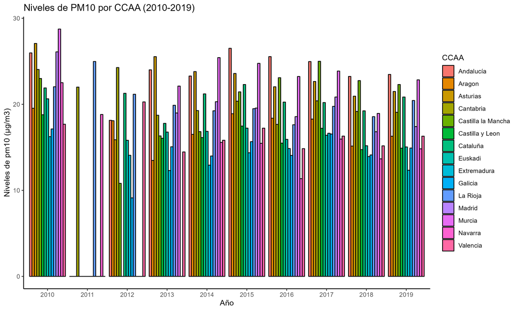

### NIVELES DE PM2.5 POR CCAA A LO LARGO DE LOS AÑOS:

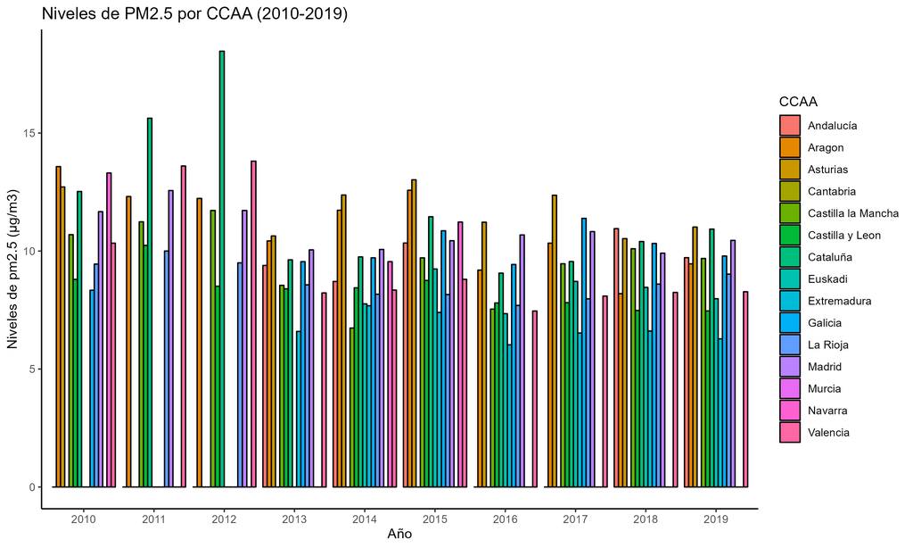

### NIVELES DE NO2 POR CCAA A LO LARGO DE LOS AÑOS:

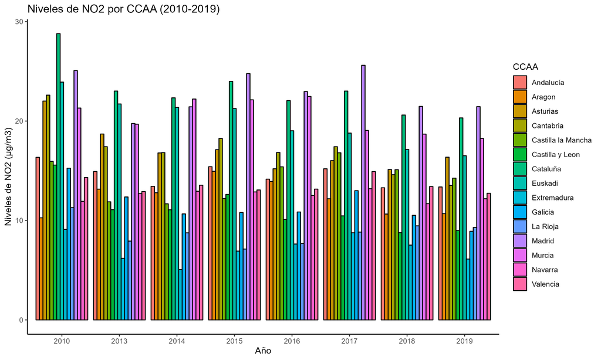

### GRAFICO NO2 JUNTO DEFUNCIONES PARA TODAS LAS CCAA

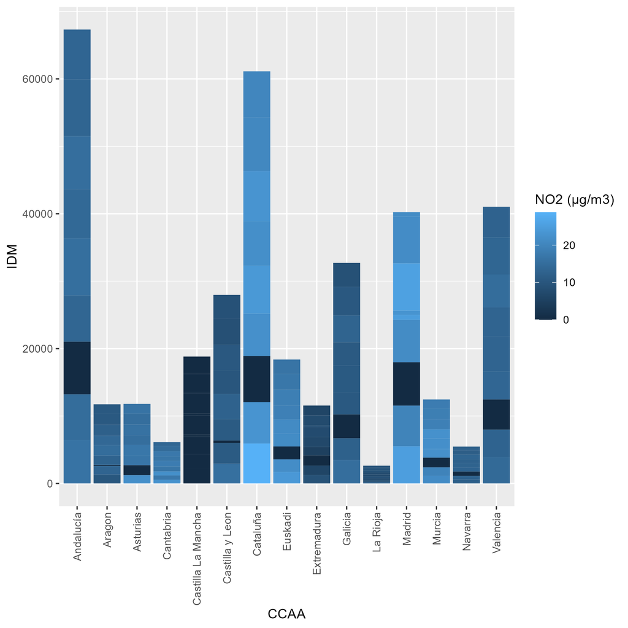

### GRAFICO PM2.5 JUNTO DEFUNCIONES PARA TODAS LAS CCAA

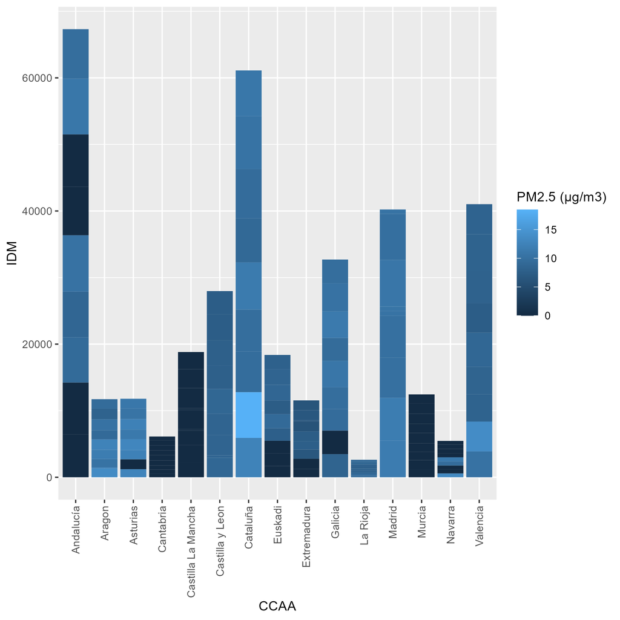

### GRAFICO PM10 JUNTO DEFUNCIONES PARA TODAS LAS CCAA

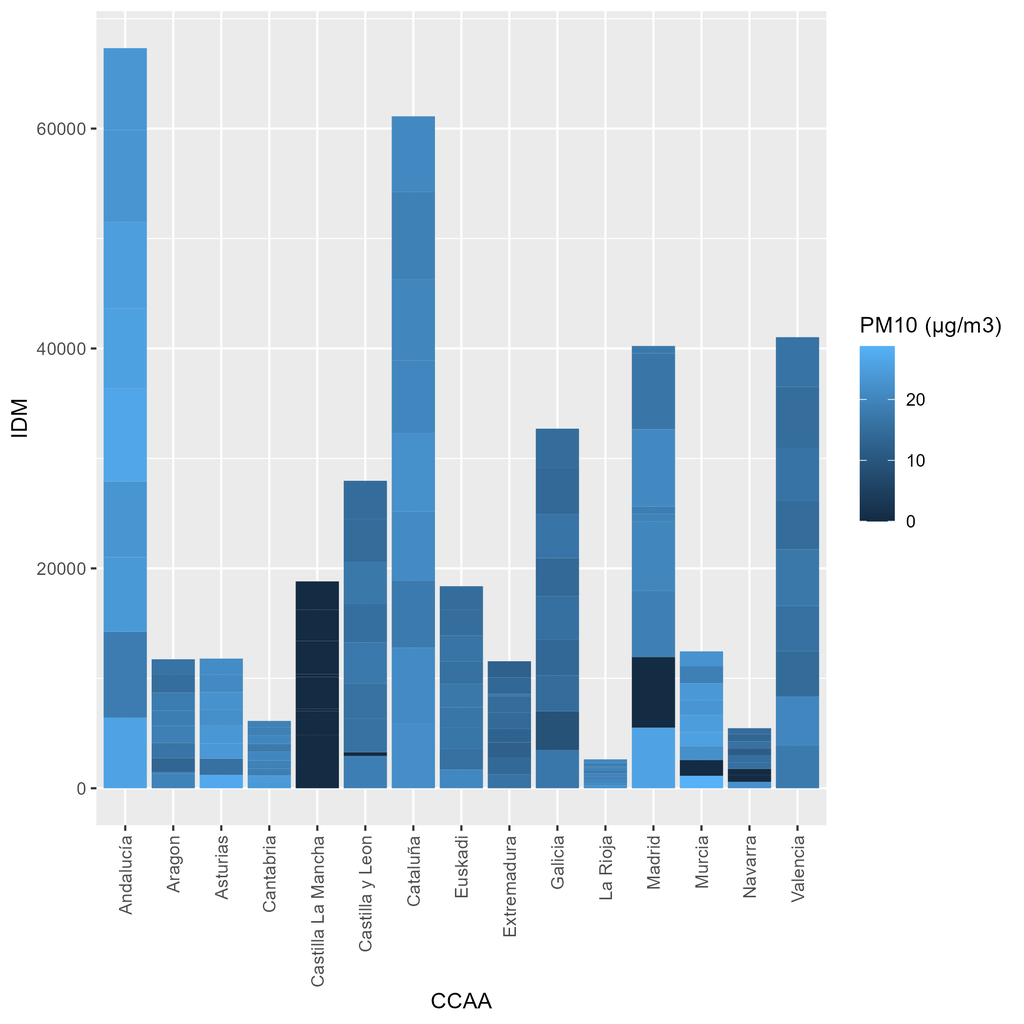